# R Notebook

HW: Each team will submit their analysis of the “trees” data set by 23/01/2021

Let’s import the iris data set and explore it

```r
data(iris)
```

we will first try to understand the structure of the data

```r
head(iris)
```

|  | Sepal.Length | Sepal.Width | Petal.Length | Petal.Width | Species |
| --- | --- | --- | --- | --- | --- |
| 1 | 5.1 | 3.5 | 1.4 | 0.2 | setosa |
| 2 | 4.9 | 3.0 | 1.4 | 0.2 | setosa |
| 3 | 4.7 | 3.2 | 1.3 | 0.2 | setosa |
| 4 | 4.6 | 3.1 | 1.5 | 0.2 | setosa |
| 5 | 5.0 | 3.6 | 1.4 | 0.2 | setosa |
| 6 | 5.4 | 3.9 | 1.7 | 0.4 | setosa |

```r
dim(iris)
```

```
[1] 150   5
```

We notice that the iris data has 5 columns and 150 observations/rows

```r
colnames(iris)
```

```
[1] "Sepal.Length" "Sepal.Width"  "Petal.Length" "Petal.Width"  "Species"
```

Let us look at some summary statistics

```r
summary(iris)
```

```
  Sepal.Length    Sepal.Width     Petal.Length    Petal.Width          Species
 Min.   :4.300   Min.   :2.000   Min.   :1.000   Min.   :0.100   setosa    :50
 1st Qu.:5.100   1st Qu.:2.800   1st Qu.:1.600   1st Qu.:0.300   versicolor:50
 Median :5.800   Median :3.000   Median :4.350   Median :1.300   virginica :50
 Mean   :5.843   Mean   :3.057   Mean   :3.758   Mean   :1.199
 3rd Qu.:6.400   3rd Qu.:3.300   3rd Qu.:5.100   3rd Qu.:1.800
 Max.   :7.900   Max.   :4.400   Max.   :6.900   Max.   :2.500
```

Another way of deriving these summary statistics is to do it one after the other using dedicated functions.

```r
min(iris$Sepal.Length)
```

```
[1] 4.3
```

```r
quantile(iris$Sepal.Length,probs=0.25)
```

```
25%
5.1
```

```r
median(iris$Sepal.Length)
```

```
[1] 5.8
```

```r
mean(iris$Sepal.Length)
```

```
[1] 5.843333
```

```r
quantile(iris$Sepal.Length,probs=0.75)
```

```
75%
6.4
```

```r
max(iris$Sepal.Length)
```

```
[1] 7.9
```

Here we notice that mode is not present in the summary. How do we compute mode?

R does not give a predefined mode function. hence we will write our own procedure

```r
names(sort(-table(iris$Sepal.Length)))[1]
```

```
[1] "5"
```

or function

```r
mode<-function(x){
  names(sort(-table(x)))[1]
}
```

```r
mode_new<-function(x){
  names(sort(table(x),decreasing = T))[1]
}
```

```r
mode(iris$Sepal.Length)
```

```
[1] "5"
```

```r
mode_new(iris$Sepal.Length)
```

```
[1] "5"
```

we can also understand the spread of the data by looking at the standard deviation, variance, range or IQR

```r
sd(iris$Sepal.Length)
```

```
[1] 0.8280661
```

```r
var(iris$Sepal.Length)
```

```
[1] 0.6856935
```

```r
range(iris$Sepal.Length)[1]-range(iris$Sepal.Length)[2]
```

```
[1] -3.6
```

```r
quantile(iris$Sepal.Length,probs=0.25)-quantile(iris$Sepal.Length,probs=0.75)
```

```
 25%
-1.3
```

Now that we have understood what the distribution looks like, we could also try to look at the data in a visual manner

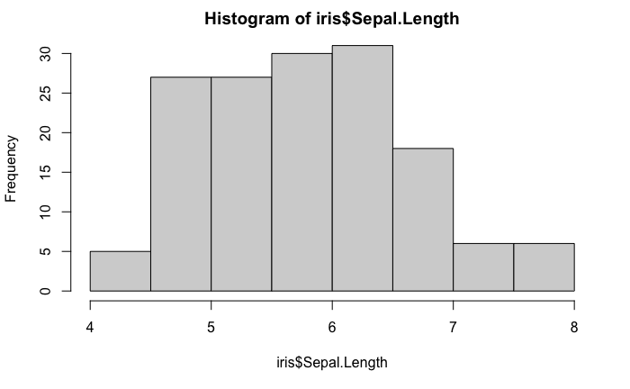

```r
hist(iris$Sepal.Length)
```

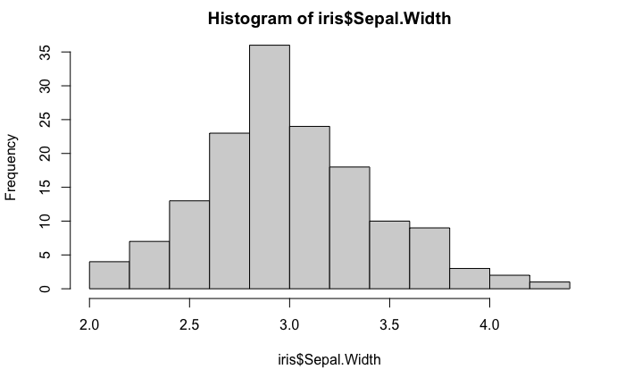

```r
hist(iris$Sepal.Width)
```

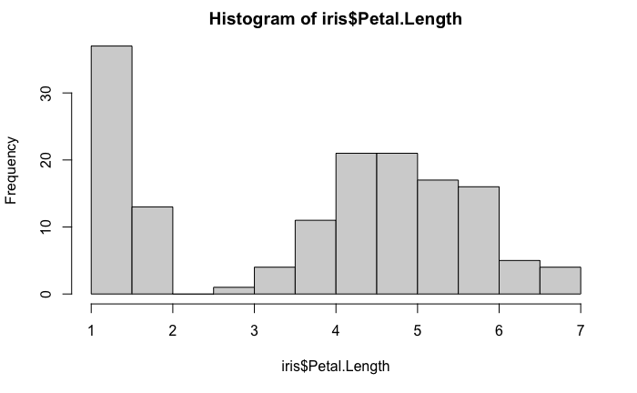

```r
hist(iris$Petal.Length)
```

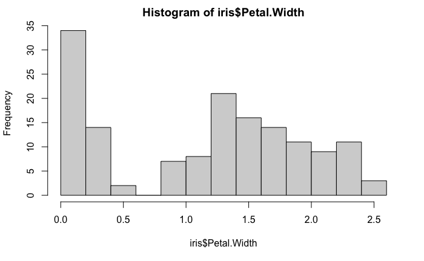

```r
hist(iris$Petal.Width)
```

A boxplot shows the above descriptive stats visually and also shows outliers. An outlier is a point that is < = (Q1 - 1.5 * IQR) or > = (Q3 + 1.5 * IQR)

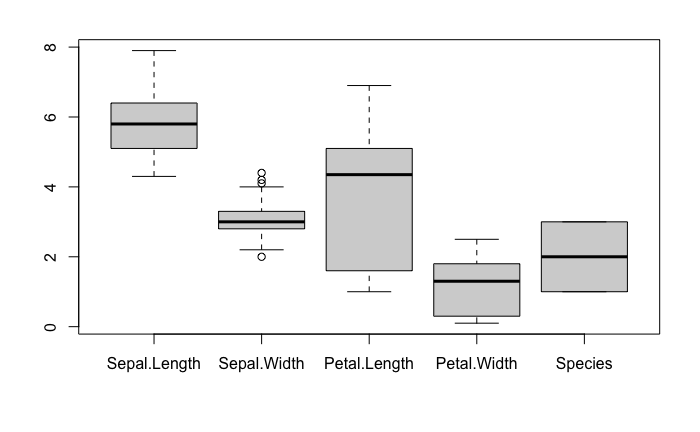

```r
boxplot(iris)
```

We can also get only the descriptives by using the .stats procedure

```r
boxplot.stats(iris$Sepal.Width)
```

```
$stats
[1] 2.2 2.8 3.0 3.3 4.0

$n
[1] 150

$conf
[1] 2.935497 3.064503

$out
[1] 4.4 4.1 4.2 2.0
```

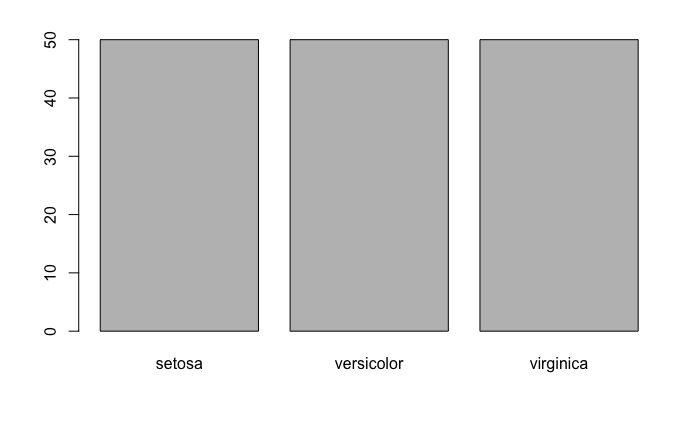

```r
plot(iris$Species)
```

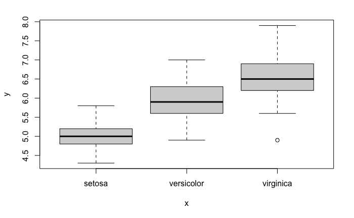

```r
plot(iris$Species,iris$Sepal.Length)
```

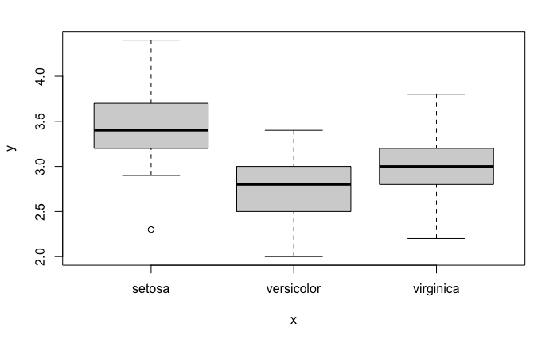

```r
plot(iris$Species,iris$Sepal.Width)
```

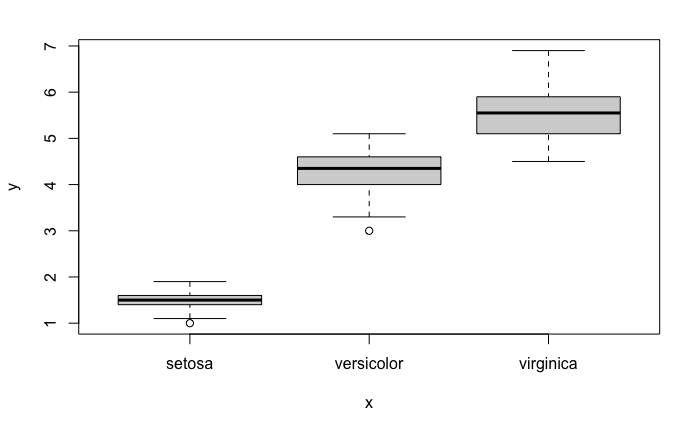

```r
plot(iris$Species,iris$Petal.Length)
```

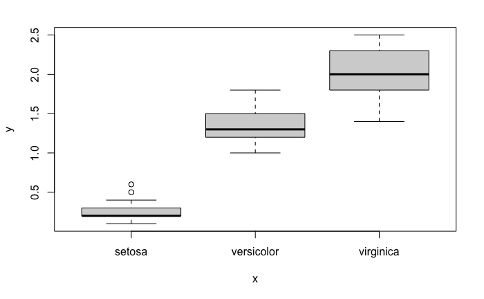

```r
plot(iris$Species,iris$Petal.Width)
```

Scatterplots and correlation

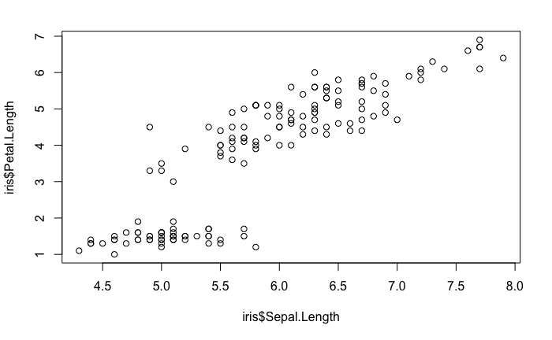

```r
plot(iris$Sepal.Length,iris$Petal.Length)
```

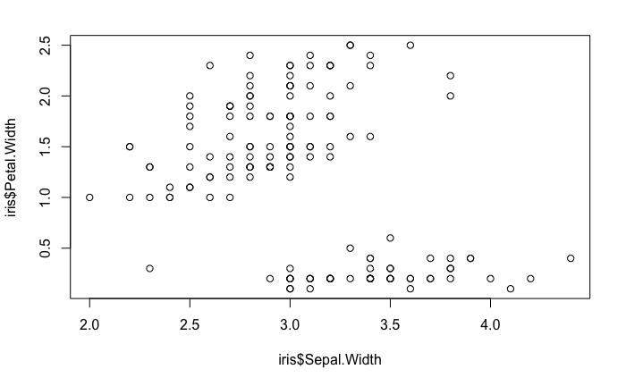

```r
plot(iris$Sepal.Width,iris$Petal.Width)
```

```r
setosa<-subset(iris,iris$Species=='setosa')
```

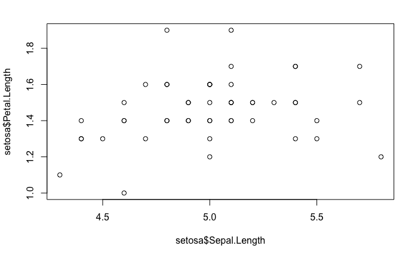

```r
plot(setosa$Sepal.Length,setosa$Petal.Length)
```

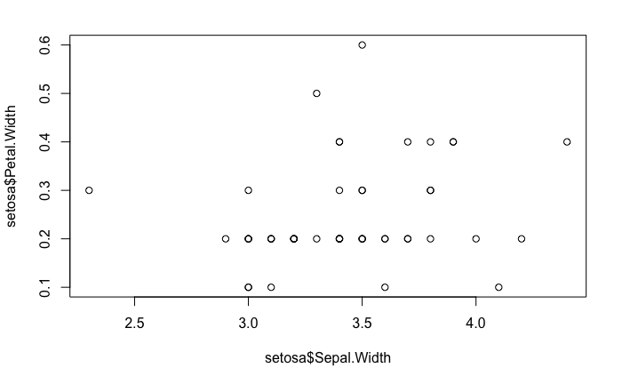

```r
plot(setosa$Sepal.Width,setosa$Petal.Width)
```

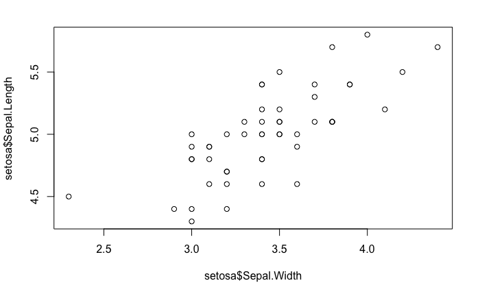

```r
plot(setosa$Sepal.Width,setosa$Sepal.Length)
```

Each scatter plot gives a sense of the correlation between two variables but doesn’t give a value to it. Also computing each correlation pair for a large data set is a lot of work, hence we use the cor() function

```r
cor(setosa[1:4])
```

```
             Sepal.Length Sepal.Width Petal.Length Petal.Width
Sepal.Length    1.0000000   0.7425467    0.2671758   0.2780984
Sepal.Width     0.7425467   1.0000000    0.1777000   0.2327520
Petal.Length    0.2671758   0.1777000    1.0000000   0.3316300
Petal.Width     0.2780984   0.2327520    0.3316300   1.0000000
```